# DAPT 622 Assignment 2

Daniel Erb

February 1, 2019

```r
# this code chunk loads the libraries used as well as reading in the necessary data
library(knitr)
library(data.table)
library(kableExtra)
library(dplyr)
library(ggplot2)
library(MASS)
library(klaR)
# set the working directory
setwd(paste("G:/My Drive/vcu/Spring 2019/Statistics/Assignments",
                    "/Assignment 2/DAPT_622_Assignment_2/",
                    sep = ""))
# file path for candy data
candy.file <- "data/CandyBars.txt"

# 75 observations, not 69 like the read.table showed...
cd <- read.csv(candy.file)

# file path for demographics data
demo.file <- "data/Demographics.txt"

# 440 observations for this data set
dd <- read.csv(demo.file)
```

# Part I

Perform a Factor Analysis on this data by carrying out the following steps:

**Factor analysis requires you choose the number of factors that you are looking for. You can’t fit the model until you decide how many factors you want to retain.**

## Question 1

How many factors should be retained (based on eigenvalues and a Scree plot)? You may use any “Factoring method” or “Rotation method” you wish. The defaults, of course, are fine.

```r
# perform principal component analysis first to allow for analysis
# of the eigenvalues and the scree plot

# remove non-continuous data
cd_sub <- cd[,c("Oz.pkg","Calories","Total.fat.g"
                  ,"Saturated.fat.g","Cholesterol.g"
                  ,"Sodium.mg","Carbohydrate.g"
                  ,"Dietary.fiber.g","Sugars.g"
                  ,"Protein.g","Vitamin.A..RDI"
                  ,"Vitamin.C..RDI","Calcium..RDI"
                  ,"Iron..RDI")]

cd_sub <- cd_sub %>%
  rename(oz = "Oz.pkg",
         kcal = "Calories",
         tot.fat = "Total.fat.g",
         sat.fat = "Saturated.fat.g",
         cholest = "Cholesterol.g",
         sodium = "Sodium.mg",
         carb = "Carbohydrate.g",
         diet.fib = "Dietary.fiber.g",
         sugar = "Sugars.g",
         protein = "Protein.g",
         vit.a = "Vitamin.A..RDI",
         vit.c = "Vitamin.C..RDI",
         calcium = "Calcium..RDI",
         iron = "Iron..RDI")

#Get variance-covariance matrix
covmat <- cov(cd_sub)
kable(covmat,caption = "Variance/Covariance Matrix for Candy Data", digits = 2) %>%
  kable_styling(bootstrap_options = c("striped", "hover", "condensed", "responsive"),
                full_width = TRUE, font_size = 8)
```

Variance/Covariance Matrix for Candy Data

|  | oz | kcal | tot.fat | sat.fat | cholest | sodium | carb | diet.fib | sugar | protein | vit.a | vit.c | calcium | iron |
| --- | --- | --- | --- | --- | --- | --- | --- | --- | --- | --- | --- | --- | --- | --- |
| oz | 1.33 | 5.80 | 0.88 | 0.75 | 1.28 | -7.25 | -0.98 | 0.06 | -0.01 | 0.05 | -0.19 | -0.80 | 1.11 | -0.37 |
| kcal | 5.80 | 3843.54 | 286.58 | 136.39 | 63.67 | 333.97 | 224.96 | 25.92 | 189.85 | 72.15 | -27.77 | -91.14 | 49.26 | 18.09 |
| tot.fat | 0.88 | 286.58 | 32.80 | 15.57 | 13.42 | 15.70 | -10.48 | 2.60 | 0.16 | 7.87 | -1.23 | -7.49 | 7.95 | 2.32 |
| sat.fat | 0.75 | 136.39 | 15.57 | 11.61 | 8.74 | -22.86 | -3.24 | 1.08 | 2.72 | 1.73 | -1.09 | -4.54 | 4.40 | 0.28 |
| cholest | 1.28 | 63.67 | 13.42 | 8.74 | 29.42 | -10.27 | -13.80 | -0.38 | 1.79 | 0.17 | 1.07 | -4.35 | 7.11 | -1.62 |
| sodium | -7.25 | 333.97 | 15.70 | -22.86 | -10.27 | 2305.41 | 31.72 | -6.14 | -26.92 | 28.24 | 16.01 | -13.77 | -34.59 | -20.49 |
| carb | -0.98 | 224.96 | -10.48 | -3.24 | -13.80 | 31.72 | 82.63 | -0.52 | 50.10 | -4.39 | -4.51 | -8.17 | -9.70 | -3.23 |
| diet.fib | 0.06 | 25.92 | 2.60 | 1.08 | -0.38 | -6.14 | -0.52 | 0.79 | -0.46 | 0.91 | -0.29 | 0.49 | 0.40 | 0.93 |
| sugar | -0.01 | 189.85 | 0.16 | 2.72 | 1.79 | -26.92 | 50.10 | -0.46 | 53.95 | -3.72 | -3.18 | -9.83 | -3.24 | -4.77 |
| protein | 0.05 | 72.15 | 7.87 | 1.73 | 0.17 | 28.24 | -4.39 | 0.91 | -3.72 | 4.41 | 0.50 | 2.00 | 3.51 | 2.36 |
| vit.a | -0.19 | -27.77 | -1.23 | -1.09 | 1.07 | 16.01 | -4.51 | -0.29 | -3.18 | 0.50 | 4.36 | 5.68 | 2.91 | 3.27 |
| vit.c | -0.80 | -91.14 | -7.49 | -4.54 | -4.35 | -13.77 | -8.17 | 0.49 | -9.83 | 2.00 | 5.68 | 34.48 | 11.58 | 9.92 |
| calcium | 1.11 | 49.26 | 7.95 | 4.40 | 7.11 | -34.59 | -9.70 | 0.40 | -3.24 | 3.51 | 2.91 | 11.58 | 15.78 | 5.08 |
| iron | -0.37 | 18.09 | 2.32 | 0.28 | -1.62 | -20.49 | -3.23 | 0.93 | -4.77 | 2.36 | 3.27 | 9.92 | 5.08 | 8.84 |

```r
#Get correlation matrix
corrmat <- cor(cd_sub)
kable(corrmat,caption = "Correlation Matrix for Candy Data", digits = 3) %>%
  kable_styling(bootstrap_options = c("striped", "hover", "condensed", "responsive"),
                full_width = TRUE, font_size = 8)
```

Correlation Matrix for Candy Data

|  | oz | kcal | tot.fat | sat.fat | cholest | sodium | carb | diet.fib | sugar | protein | vit.a | vit.c | calcium | iron |
| --- | --- | --- | --- | --- | --- | --- | --- | --- | --- | --- | --- | --- | --- | --- |
| oz | 1.000 | 0.081 | 0.134 | 0.192 | 0.204 | -0.131 | -0.093 | 0.054 | -0.001 | 0.019 | -0.080 | -0.118 | 0.243 | -0.108 |
| kcal | 0.081 | 1.000 | 0.807 | 0.646 | 0.189 | 0.112 | 0.399 | 0.470 | 0.417 | 0.554 | -0.214 | -0.250 | 0.200 | 0.098 |
| tot.fat | 0.134 | 0.807 | 1.000 | 0.798 | 0.432 | 0.057 | -0.201 | 0.509 | 0.004 | 0.654 | -0.103 | -0.223 | 0.349 | 0.136 |
| sat.fat | 0.192 | 0.646 | 0.798 | 1.000 | 0.473 | -0.140 | -0.105 | 0.355 | 0.109 | 0.242 | -0.153 | -0.227 | 0.325 | 0.028 |
| cholest | 0.204 | 0.189 | 0.432 | 0.473 | 1.000 | -0.039 | -0.280 | -0.079 | 0.045 | 0.015 | 0.095 | -0.137 | 0.330 | -0.100 |
| sodium | -0.131 | 0.112 | 0.057 | -0.140 | -0.039 | 1.000 | 0.073 | -0.144 | -0.076 | 0.280 | 0.160 | -0.049 | -0.181 | -0.144 |
| carb | -0.093 | 0.399 | -0.201 | -0.105 | -0.280 | 0.073 | 1.000 | -0.064 | 0.750 | -0.230 | -0.237 | -0.153 | -0.269 | -0.120 |
| diet.fib | 0.054 | 0.470 | 0.509 | 0.355 | -0.079 | -0.144 | -0.064 | 1.000 | -0.070 | 0.486 | -0.156 | 0.093 | 0.114 | 0.351 |
| sugar | -0.001 | 0.417 | 0.004 | 0.109 | 0.045 | -0.076 | 0.750 | -0.070 | 1.000 | -0.241 | -0.207 | -0.228 | -0.111 | -0.218 |
| protein | 0.019 | 0.554 | 0.654 | 0.242 | 0.015 | 0.280 | -0.230 | 0.486 | -0.241 | 1.000 | 0.115 | 0.162 | 0.420 | 0.378 |
| vit.a | -0.080 | -0.214 | -0.103 | -0.153 | 0.095 | 0.160 | -0.237 | -0.156 | -0.207 | 0.115 | 1.000 | 0.463 | 0.350 | 0.527 |
| vit.c | -0.118 | -0.250 | -0.223 | -0.227 | -0.137 | -0.049 | -0.153 | 0.093 | -0.228 | 0.162 | 0.463 | 1.000 | 0.496 | 0.568 |
| calcium | 0.243 | 0.200 | 0.349 | 0.325 | 0.330 | -0.181 | -0.269 | 0.114 | -0.111 | 0.420 | 0.350 | 0.496 | 1.000 | 0.430 |
| iron | -0.108 | 0.098 | 0.136 | 0.028 | -0.100 | -0.144 | -0.120 | 0.351 | -0.218 | 0.378 | 0.527 | 0.568 | 0.430 | 1.000 |

```r
# perform pca
pca <- prcomp(cd_sub, scale = TRUE)
summary(pca)
```

```
## Importance of components:
##                           PC1    PC2    PC3    PC4     PC5     PC6     PC7
## Standard deviation     1.9221 1.7087 1.3362 1.2073 1.12325 0.94057 0.75379
## Proportion of Variance 0.2639 0.2086 0.1275 0.1041 0.09012 0.06319 0.04059
## Cumulative Proportion  0.2639 0.4724 0.5999 0.7041 0.79419 0.85738 0.89797
##                           PC8     PC9    PC10    PC11    PC12    PC13
## Standard deviation     0.6546 0.59533 0.51741 0.40269 0.39001 0.24643
## Proportion of Variance 0.0306 0.02532 0.01912 0.01158 0.01087 0.00434
## Cumulative Proportion  0.9286 0.95389 0.97301 0.98459 0.99546 0.99980
##                           PC14
## Standard deviation     0.05354
## Proportion of Variance 0.00020
## Cumulative Proportion  1.00000
```

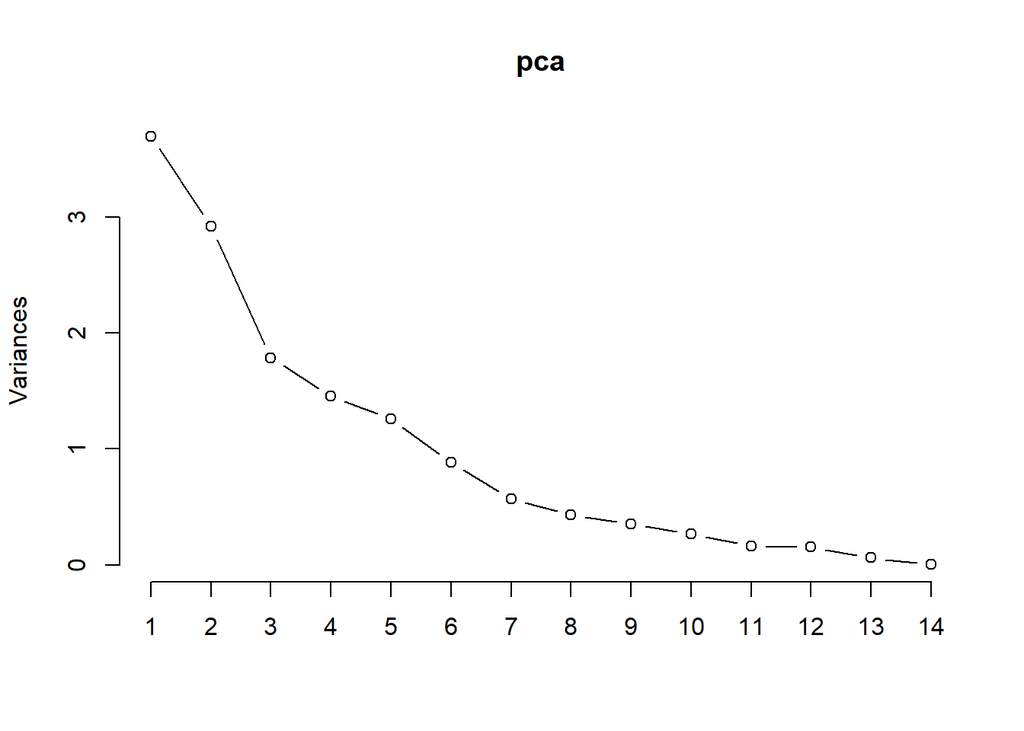

```r
# create a screeplot
screeplot(pca, npcs = 14, type = "lines")
```

```r
cd_fa <- factanal(cd_sub, factors = 3, rotation = "varimax", scores = c("regression"))
```

As we have seen in our previous assignment, approximately 60% of the variability in the data can be explained through the use of 3 principal components. This would suggest that we might target 3 final factors when performing our factor analysis. If greater explanatory power is necessary, 5 factors would help explain about 80% of the variability in the data. For this particular analysis, 3 factos will be used with the varimax rotation.

## Question 2

Provide the rotated factor loadings matrix. You should notice that (as compared with Principal Component Analysis) fewer variables load onto each factor. Interpret (as best as possible) your factors. Can you give an overall name to each factor?

```r
cd_fa$loadings
```

```
##
## Loadings:
##          Factor1 Factor2 Factor3
## oz                0.189
## kcal      0.657   0.418   0.624
## tot.fat   0.654   0.746   0.104
## sat.fat   0.252   0.822   0.213
## cholest           0.606
## sodium    0.293  -0.195
## carb             -0.350   0.933
## diet.fib  0.497   0.244
## sugar    -0.107           0.792
## protein   0.982          -0.172
## vit.a            -0.158  -0.311
## vit.c     0.129  -0.366  -0.294
## calcium   0.386   0.166  -0.201
## iron      0.365  -0.116  -0.151
##
##                Factor1 Factor2 Factor3
## SS loadings      2.539   2.231   2.227
## Proportion Var   0.181   0.159   0.159
## Cumulative Var   0.181   0.341   0.500
```

```r
pca$rotation
```

```
##                   PC1          PC2         PC3         PC4          PC5
## oz        0.113317669  0.053686539 -0.31479891  0.22725401 -0.107033419
## kcal      0.402836701  0.284073580  0.25837994  0.01585576  0.110727490
## tot.fat   0.486633265  0.118536793 -0.06746888 -0.13511138  0.050603309
## sat.fat   0.402953791  0.176695640 -0.18575154  0.11183965 -0.014600317
## cholest   0.218347101  0.044914231 -0.45119326  0.22086892  0.342005105
## sodium   -0.011505264  0.012867318  0.14223866 -0.48068412  0.617539040
## carb     -0.103343004  0.342723490  0.47912344  0.27583793  0.126148031
## diet.fib  0.318917895 -0.003342341  0.23296724 -0.15167987 -0.472640353
## sugar    -0.016771089  0.380444122  0.27928444  0.43686736  0.186794863
## protein   0.378882228 -0.140404113  0.20068771 -0.32823909  0.072050365
## vit.a     0.014183410 -0.405814738  0.07181759  0.15558865  0.415726502
## vit.c     0.009298491 -0.446008539  0.23631870  0.23069808 -0.009375739
## calcium   0.295812179 -0.281099565 -0.06512421  0.36862151  0.113181078
## iron      0.184055124 -0.380022355  0.32237363  0.16279476 -0.100375583
##                   PC6          PC7           PC8          PC9         PC10
## oz        0.838655887 -0.289398358  0.0657840828  0.044124905 -0.072285484
## kcal      0.029047686 -0.005754639 -0.1193632619  0.008884305 -0.103451905
## tot.fat  -0.108964683 -0.024126316 -0.1087569891  0.013726192  0.053898093
## sat.fat  -0.230548505 -0.074454426  0.0002012423  0.677985055  0.045554985
## cholest  -0.251920954 -0.010686959  0.4361946041 -0.436644024 -0.312748944
## sodium    0.247673005  0.001228510  0.3366950146  0.246044055 -0.087631567
## carb      0.117733825 -0.020509253  0.0189175792  0.075529124 -0.281739169
## diet.fib  0.007165189 -0.208733364  0.5635470341 -0.138821018  0.297098616
## sugar    -0.016123264  0.016596450  0.0931241649 -0.228307178  0.372913995
## protein   0.214399737  0.218292716 -0.2548454181 -0.387472448  0.048742593
## vit.a    -0.073700038 -0.551044730 -0.1194791883  0.003058837  0.466383436
## vit.c     0.053544582  0.394448631  0.4549524673  0.240133036 -0.002101877
## calcium   0.157777129  0.459838585 -0.2045179607  0.029507988  0.121599048
## iron     -0.112465080 -0.383881847 -0.1064021875 -0.033871761 -0.576377972
##                 PC11        PC12         PC13         PC14
## oz        0.13872214 -0.06297655  0.008413763  0.014228504
## kcal     -0.06152000 -0.29772247  0.275700845 -0.695278779
## tot.fat   0.21490915 -0.08895875  0.571074679  0.562286844
## sat.fat   0.07835265  0.03937079 -0.480438153  0.015390226
## cholest  -0.09096198 -0.11354884 -0.132242302 -0.003444134
## sodium   -0.03126087  0.34660067  0.052175461 -0.017408731
## carb     -0.41183009 -0.27744157 -0.135026918  0.431010662
## diet.fib -0.32810680  0.14326108 -0.024849851  0.008389245
## sugar     0.45702928  0.37131318 -0.063095806 -0.010437474
## protein   0.16978565 -0.16312194 -0.551014291  0.115752612
## vit.a    -0.15022729 -0.26276157 -0.017991310  0.010168995
## vit.c     0.34532255 -0.37739283  0.083922915  0.003321935
## calcium  -0.46995769  0.39104796  0.113725160 -0.001819807
## iron      0.19431391  0.37220813  0.003615515 -0.014168783
```

When compared to the loadings matrices between the factor analysis and the principal component analysis, we see that the various factors have fewer included variables than the principal components. For example, the first factor does not include any loading for ounces, cholesterol, carbohydrates, or vitamin A, where the first principal component includes all variables within the data set. This does not, however, take into account that several of the loadings in the principal component analysis are very close to 0 in magnitude. Given the relatively high loadings for calories, total fat and protein, the first factor could be thought of as protein and fat content, since both may contribute to calorie count. The second factor has high positive loadings for saturated fat, total fat. This factor could be thought of as fat content. The third factor contains high loadings for calories, carbohydrates, and sugars. This factor might be thought of as carbohydrates since sugars are a type of carbohydrate and carbohydrates contribute to the overall calorie count.

## Question 3

Plot factor scores for your first two factors. Color the points by Brand. Are there any natural groupings of observations?

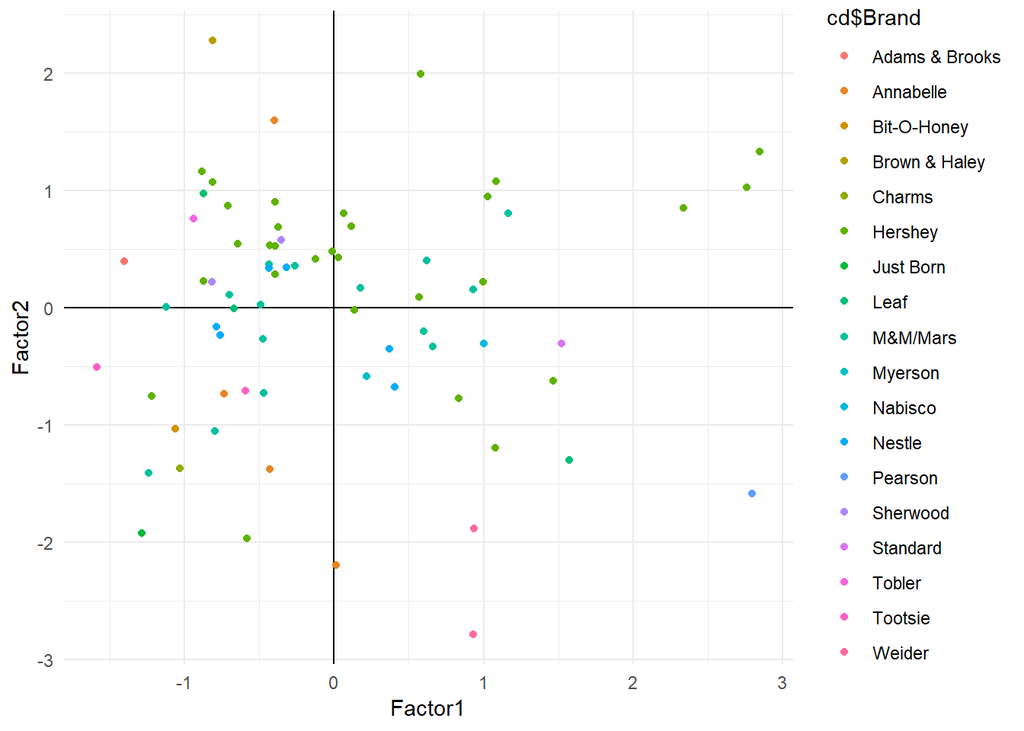

```r
ggplot(data=as.data.frame(cd_fa$scores), aes(x=Factor1, y=Factor2,color = cd$Brand)) +
  geom_hline(yintercept=0) +
  geom_vline(xintercept=0) +
  geom_point() +
  theme_minimal()
```

There do not seem to be any extremely strong groupings within the data set. There are three candy bars that Hershey produces, which seem to be similar in both factors. There are also two candy bars produced by Weider that are similiar in both factors. Most of the data is fairly well scattered, with no other natural groupings based on brand.

# Part II

## Question 1

Perform a linear discriminant analysis using the highlighted variables for discriminating the variable Pop_Size_Group.

```r
names(dd)
```

```
##  [1] "County_name"           "State"
##  [3] "Region_num"            "Location"
##  [5] "Square_miles"          "Population"
##  [7] "Pop_Size_Group"        "Pct_Age18_to_34"
##  [9] "Pct_65_or_over"        "Num_physicians"
## [11] "Num_hospital_beds"     "Num_serious_crimes"
## [13] "Pct_High_Sch_grads"    "Pct_Bachelors"
## [15] "Pct_below_poverty"     "Pct_unemployed"
## [17] "Per_cap_income"        "Total_personal_income"
```

```r
dd_sub <- dd %>%
  dplyr::select(Pop_Size_Group,Pct_Age18_to_34,Pct_65_or_over,Num_physicians,Num_hospital_beds,
         Num_serious_crimes,Pct_High_Sch_grads,Pct_Bachelors,Pct_below_poverty,
         Pct_unemployed,Per_cap_income,Total_personal_income)

lin.da <- lda(Pop_Size_Group ~ ., data = dd_sub)

discrim.values <- predict(lin.da,dd_sub)

ct <- table(dd_sub$Pop_Size_Group,discrim.values$class)

sum(diag(prop.table(ct)))
```

```
## [1] 0.6590909
```

- Pct_Age18_to_34
- Pct_65_or_over
- Num_physicians
- Num_hospital_beds
- Num_serious_crimes
- Pct_High_Sch_grads
- Pct_Bachelors
- Pct_below_poverty
- Pct_unemployed
- Per_cap_1990income
- Total_personal_income

## Question 2

Show a plot of the two discriminant functions with points colored by Pop_Size_Group. Do both discriminant functions appear necessary to describe group separation?

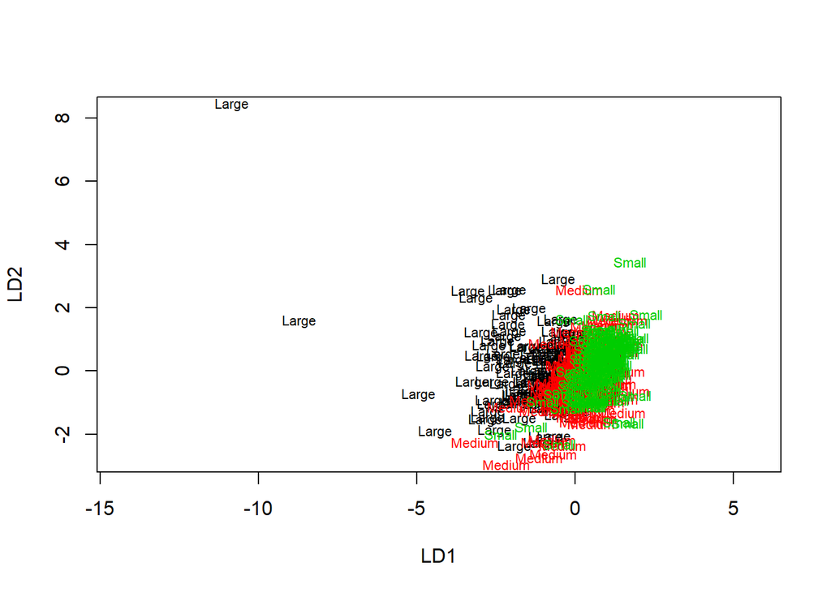

```r
t.discrim.values <- as.data.frame(cbind(as.character(discrim.values$class),discrim.values$x)) %>%
  rename(Pop_Size_Group = V1)


plot(lin.da, col = as.integer(dd_sub$Pop_Size_Group))
```

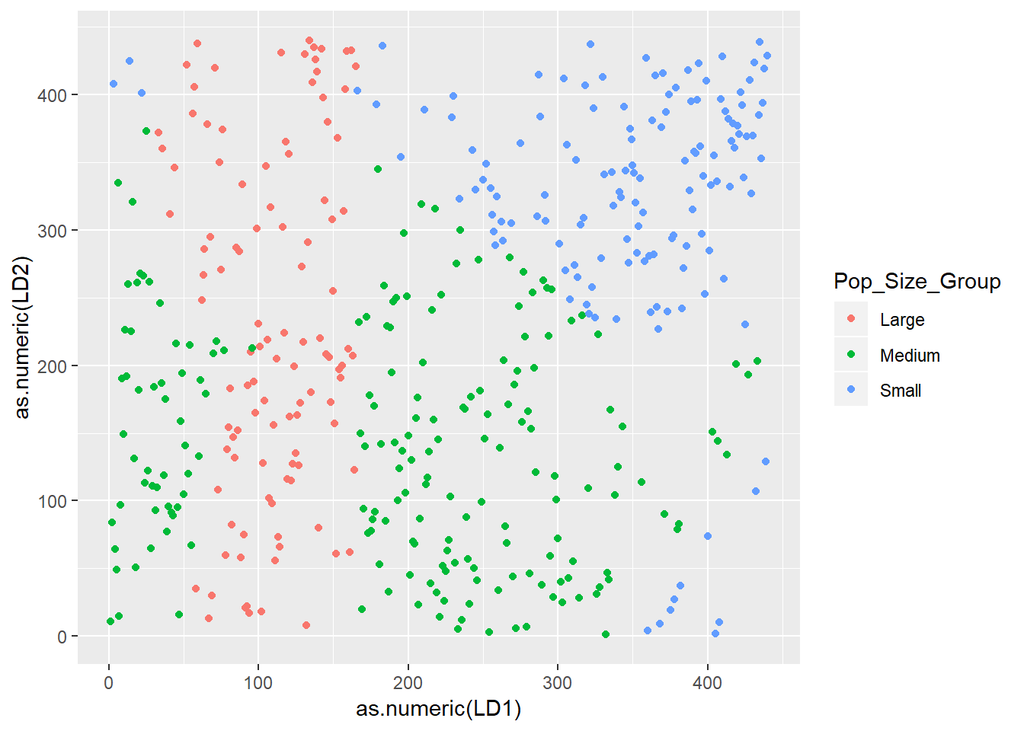

```r
ggplot(t.discrim.values, aes(x = as.numeric(LD1),y = as.numeric(LD2), color = Pop_Size_Group)) +
  geom_point()
```

## Question 3

Give the scoring coefficients for the two discriminant functions. Which variables appear most important for describing group separation?

## Question 4

Provide a classification matrix and the percent of observations misclassified.